# 6.0 Predict Restored DO Time Series

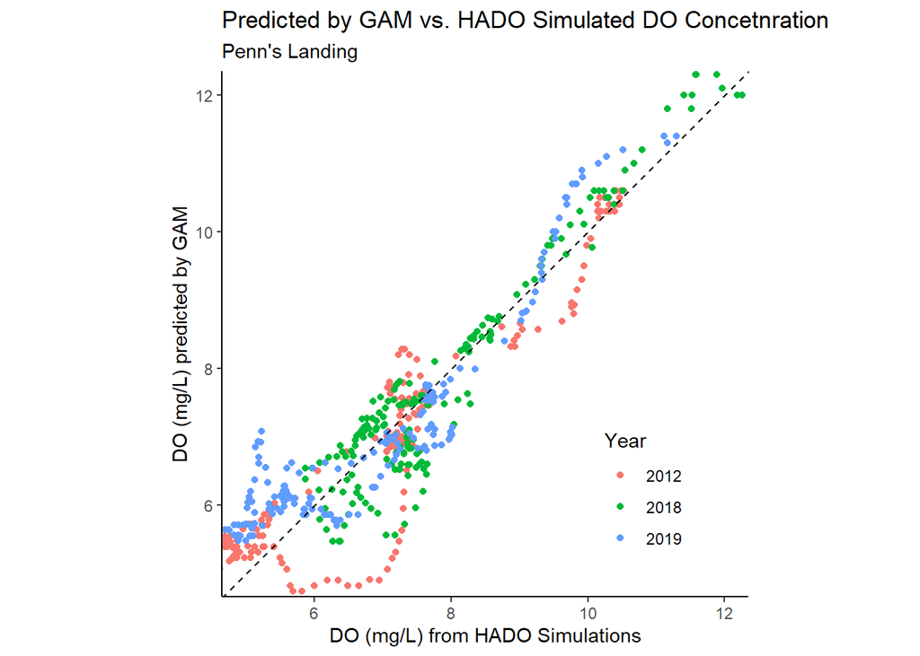

```r
# Show predicted vs. observed with the 1:1 line.
df.Penn %>% filter(!is.na(do.HADO)) %>%
ggplot(aes(x=do.HADO,y=do.pred,color=droplevels(year)))+
  geom_point()+
  geom_abline(slope=1,intercept=0,linetype=2)+
  guides(color=guide_legend(title="Year"))+
  coord_fixed(xlim=c(5,12),ylim=c(5,12))+
  theme_classic()+
  theme(legend.position=c(0.8,0.2))+
  labs(x="DO (mg/L) from HADO Simulations",y="DO (mg/L) predicted by GAM")+
  ggtitle("Predicted by GAM vs. HADO Simulated DO Concetnration",
          subtitle="Penn's Landing")
```

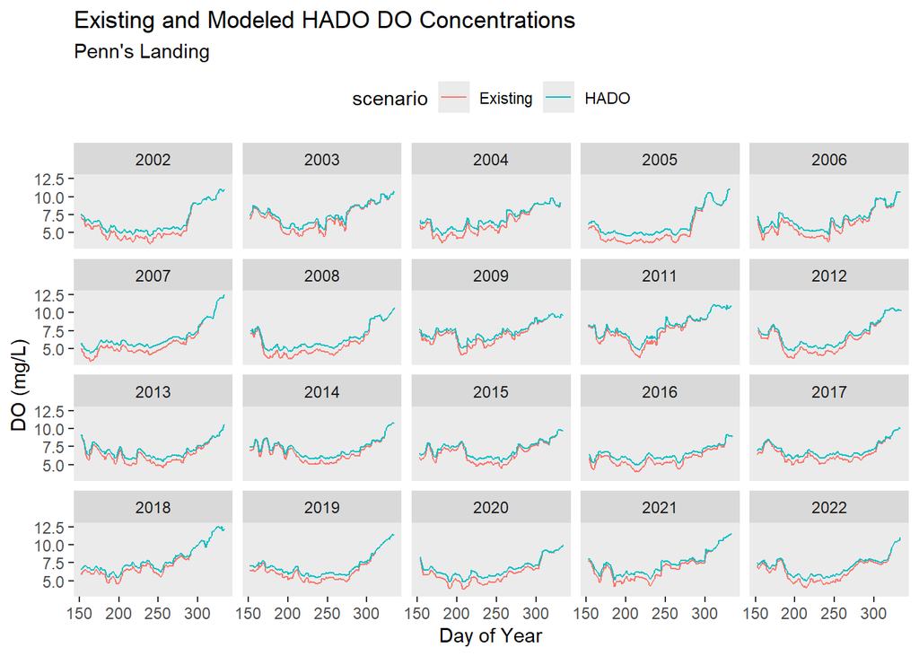

```r
# Graph the existing and modeled HADO DO Concentrations
df.Penn %>% select(year,doy,do.obs,do.pred) %>%
  pivot_longer(cols=c("do.obs","do.pred"),names_to = "scenario",values_to="do.mgL") %>%
  mutate(scenario=factor(scenario,levels=c("do.obs","do.pred"),labels=c("Existing","HADO"))) %>%
ggplot()+
  geom_line(aes(x=doy,y=do.mgL,color=scenario))+
  facet_wrap(~year)+
  labs(x="Day of Year",y="DO (mg/L)")+
  nogrid+
  theme(legend.position="top")+
  ggtitle("Existing and Modeled HADO DO Concentrations",subtitle="Penn's Landing")
```

```r
# Calculate the 10th Percentile DO for every year in observed and HADO
p.10 <- df.Penn %>%
  group_by(year) %>%
  summarize(HADO.10=quantile(do.pred,prob=0.1,na.rm=TRUE),
            OBS.10=quantile(do.obs,prob=0.1,na.rm=TRUE),
            MOD.10=quantile(do.HADO,prob=0.1,na.rm=TRUE)) %>%
  mutate(delta_DO=HADO.10-OBS.10)
knitr::kable(p.10,caption="Estimates of 10th Percentile DO (mg/L)")
```

Estimates of 10th Percentile DO (mg/L)

| year | HADO.10 | OBS.10 | MOD.10 | delta_DO |
| --- | --- | --- | --- | --- |
| 2002 | 5.082695 | 4.120000 | NA | 0.9626955 |
| 2003 | 5.718280 | 4.900000 | NA | 0.8182796 |
| 2004 | 5.244331 | 4.298571 | NA | 0.9457590 |
| 2005 | 4.734525 | 3.700000 | NA | 1.0345245 |
| 2006 | 5.286707 | 4.360000 | NA | 0.9267068 |
| 2007 | 5.143083 | 4.167826 | NA | 0.9752573 |
| 2008 | 4.922891 | 3.915000 | NA | 1.0078912 |
| 2009 | 6.152693 | 5.320000 | NA | 0.8326926 |
| 2011 | 6.224601 | 5.500000 | NA | 0.7246005 |
| 2012 | 5.063049 | 4.100000 | 4.737334 | 0.9630495 |
| 2013 | 5.810194 | 5.000000 | NA | 0.8101945 |
| 2014 | 5.943616 | 5.200000 | NA | 0.7436160 |
| 2015 | 5.861729 | 5.100000 | NA | 0.7617291 |
| 2016 | 5.422702 | 4.520000 | NA | 0.9027019 |
| 2017 | 6.103310 | 5.400000 | NA | 0.7033104 |
| 2018 | 6.189045 | 5.500000 | 6.467219 | 0.6890449 |
| 2019 | 5.710194 | 4.900000 | 5.063912 | 0.8101938 |
| 2020 | 5.388228 | 4.500000 | NA | 0.8882278 |
| 2021 | 5.763106 | 4.900000 | NA | 0.8631059 |
| 2022 | 5.533864 | 4.700000 | NA | 0.8338636 |

```r
# Summary statistics for change in 10th percentile DO
summary(p.10$delta_DO)
```

```
##    Min. 1st Qu.  Median    Mean 3rd Qu.    Max.
##  0.6890  0.7981  0.8485  0.8599  0.9500  1.0345
```

```r
# Calculate the median DO for every year in observed and HADO
med <- df.Penn %>%
  group_by(year) %>%
  summarize(HADO.med=quantile(do.pred,prob=0.5,na.rm=TRUE),
            OBS.med=quantile(do.obs,prob=0.5,na.rm=TRUE),
            MOD.med=quantile(do.HADO,prob=0.5,na.rm=TRUE)) %>%
  mutate(delta_DO=HADO.med-OBS.med)
knitr::kable(med,caption="Estimates of Median DO (mg/L)")
```

Estimates of Median DO (mg/L)

| year | HADO.med | OBS.med | MOD.med | delta_DO |
| --- | --- | --- | --- | --- |
| 2002 | 5.753701 | 4.900000 | NA | 0.8537009 |
| 2003 | 7.422098 | 6.916667 | NA | 0.5054314 |
| 2004 | 6.620966 | 5.925000 | NA | 0.6959661 |
| 2005 | 5.294188 | 4.400000 | NA | 0.8941877 |
| 2006 | 6.728845 | 6.100000 | NA | 0.6288450 |
| 2007 | 6.012687 | 5.286956 | NA | 0.7257302 |
| 2008 | 5.623226 | 4.800000 | NA | 0.8232257 |
| 2009 | 7.395865 | 7.000000 | NA | 0.3958645 |
| 2011 | 8.063529 | 7.800000 | NA | 0.2635287 |
| 2012 | 6.904323 | 6.400000 | 7.139759 | 0.5043229 |
| 2013 | 6.829056 | 6.200000 | NA | 0.6290560 |
| 2014 | 7.110370 | 6.600000 | NA | 0.5103703 |
| 2015 | 7.315346 | 6.900000 | NA | 0.4153456 |
| 2016 | 6.195714 | 5.500000 | NA | 0.6957138 |
| 2017 | 6.667835 | 6.100000 | NA | 0.5678349 |
| 2018 | 7.349423 | 6.800000 | 7.395356 | 0.5494233 |
| 2019 | 6.660506 | 6.100000 | 6.639698 | 0.5605063 |
| 2020 | 6.439347 | 5.800000 | NA | 0.6393472 |
| 2021 | 7.300478 | 6.800000 | NA | 0.5004781 |
| 2022 | 7.024782 | 6.500000 | NA | 0.5247824 |

```r
# Summary statistics for change in median DO
summary(med$delta_DO)
```

```
##    Min. 1st Qu.  Median    Mean 3rd Qu.    Max.
##  0.2635  0.5052  0.5642  0.5942  0.6958  0.8942
```

# Save the estimates of restored DO in an R Data set

```r
restoredWQ <- rbind(df.Penn,df.Chester) %>%
  select(Site,date,doy,year,do.pred,sal.obs,wt.obs) %>%
  filter(complete.cases(.)) %>%
  rename(do.mean=do.pred,sal.mean=sal.obs,wt.mean=wt.obs) %>%
  mutate(posat.mean=do.mean*100/gas_O2sat(S=sal.mean,t=wt.mean))

save(restoredWQ,file=here("data","6.0 Estimates of Restored DO.Rdata"))
```

# Calculate statistics on Observed and Restored DO

- needed for Technical Support Document

```r
# Build single file with observed data
df.obs <- rbind(
drc_summer %>%
  select(date,posat.mean) %>%
  mutate(Site="Chester"),
drpl_summer %>%
  select(date,posat.mean) %>%
  mutate(Site="Penn's Landing")
) %>% mutate(type="Observed")

# Build identical file with restored data
df.res <- restoredWQ %>%
    select(date,posat.mean,Site)

# Combine, transpose, and calculate difference
df <- rbind(df.obs %>% mutate(type="Observed"),
            df.res %>% mutate(type="Restored")) %>%
  pivot_wider(id_cols=all_of(c("Site","date")),
               names_from = "type",
               values_from = "posat.mean") %>%
  mutate(change=Restored-Observed)

names(df) <- c("Site","date","Observed.POSAT","Restored.POSAT","Change.POSAT")
```

# Repeat above steps for DO mg/L

```r
# Build single file with observed data
df.obs <- rbind(
drc_summer %>%
  select(date,do.mgL.mean) %>%
  mutate(Site="Chester"),
drpl_summer %>%
  select(date,do.mgL.mean) %>%
  mutate(Site="Penn's Landing")
) %>% mutate(type="Observed")

# Build identical file with restored data
df.res <- restoredWQ %>%
    select(date,do.mean,Site) %>%
    rename(do.mgL.mean=do.mean)

# Combine, transpose, and calculate difference
df.do <- rbind(df.obs %>% mutate(type="Observed"),
            df.res %>% mutate(type="Restored")) %>%
  pivot_wider(id_cols=all_of(c("Site","date")),
               names_from = "type",
               values_from = "do.mgL.mean") %>%
  mutate(change=Restored-Observed)

names(df.do) <- c("Site","date","Observed.DO.mgL","Restored.DO.mgL","Change.DO.mgL")

df <- cbind(df,select(df.do,-date,-Site)) %>%
  mutate(Site=factor(Site)) %>%
  mutate(season=cut(yday(date),breaks=c(1,181,305,366),labels=c("Spawning","Growth","Overwinter")))
```

# Calculate statistics on differences during growth season

Differences were calculated for estimates from July 1 to October 31. Under the restored scenario, POSAT was projected to increase from the observed data by 9.3% with a 95% confidence interval of (9.14,9.38). DO (mg/L) in the restored scenario was projected to increase from the observed data by 0.74 mg/L with a 95% confidence interval of (0.731,0.750). Compared to Chester, the increase in POSAT was 2.33% (+/- 0.119) less at Penn’s Landing. Similarly, the increase in DO (mg/L) was 0.18mg/L less at Penn’s Landing than at Chester.

```r
# Define a variable for just the growth season
df.growth <- df %>% filter(season=="Growth")

# Show estimates and confidence interval for POSAT and DO
t.test(df.growth$Change.POSAT)
```

```
##
##  One Sample t-test
##
## data:  df.growth$Change.POSAT
## t = 149.68, df = 5083, p-value < 2.2e-16
## alternative hypothesis: true mean is not equal to 0
## 95 percent confidence interval:
##  9.142939 9.385619
## sample estimates:
## mean of x
##  9.264279
```

```r
t.test(df.growth$Change.DO.mgL)
```

```
##
##  One Sample t-test
##
## data:  df.growth$Change.DO.mgL
## t = 154.81, df = 5083, p-value < 2.2e-16
## alternative hypothesis: true mean is not equal to 0
## 95 percent confidence interval:
##  0.7314589 0.7502227
## sample estimates:
## mean of x
## 0.7408408
```

```r
# Calculate for differences by Site
fit <- lm(Change.POSAT ~ Site,data=df.growth)
summary(fit)
```

```
##
## Call:
## lm(formula = Change.POSAT ~ Site, data = df.growth)
##
## Residuals:
##      Min       1Q   Median       3Q      Max
## -10.4003  -2.9967   0.5786   2.9220  21.5295
##
## Coefficients:
##                    Estimate Std. Error t value Pr(>|t|)
## (Intercept)        10.40028    0.08343   124.7   <2e-16 ***
## SitePenn's Landing -2.32881    0.11945   -19.5   <2e-16 ***
## ---
## Signif. codes:  0 '***' 0.001 '**' 0.01 '*' 0.05 '.' 0.1 ' ' 1
##
## Residual standard error: 4.257 on 5082 degrees of freedom
## Multiple R-squared:  0.06959,    Adjusted R-squared:  0.0694
## F-statistic: 380.1 on 1 and 5082 DF,  p-value: < 2.2e-16
```

```r
fit <- lm(Change.DO.mgL ~ Site,data=df.growth)
summary(fit)
```

```
##
## Call:
## lm(formula = Change.DO.mgL ~ Site, data = df.growth)
##
## Residuals:
##      Min       1Q   Median       3Q      Max
## -0.82856 -0.21632  0.04704  0.21775  1.93618
##
## Coefficients:
##                     Estimate Std. Error t value Pr(>|t|)
## (Intercept)         0.828562   0.006451  128.43   <2e-16 ***
## SitePenn's Landing -0.179828   0.009237  -19.47   <2e-16 ***
## ---
## Signif. codes:  0 '***' 0.001 '**' 0.01 '*' 0.05 '.' 0.1 ' ' 1
##
## Residual standard error: 0.3292 on 5082 degrees of freedom
## Multiple R-squared:  0.06941,    Adjusted R-squared:  0.06922
## F-statistic:   379 on 1 and 5082 DF,  p-value: < 2.2e-16
```

```r
#
df %>% group_by(Site) %>%
  summarize(Change.POSAT=mean(Change.POSAT,na.rm=TRUE),
            Change.DO.mgL=mean(Change.DO.mgL,na.rm=TRUE))
```

| Site | Change.POSAT | Change.DO.mgL |
| --- | --- | --- |
| Chester | 8.605633 | 0.6869553 |
| Penn's Landing | 6.732233 | 0.5418121 |